# assignment#01(1)

## Question 1

**Take the solar radiation data from File a, and copy it into File c, and run the power spectrum tool to find out which frequencies are important**.

```python
import numpy as np
import pandas as pd
import matplotlib.pyplot as plt

solar_radia2017 = pd.read_excel('HalfHourSolarRadiation2017.xlsx',sheet_name='Sheet1')
```

Discrete Fourier transform, using the power value as a measure of power in solar radiation

```python
import math

def calculate_dft(data, num_frequencies):
    num_data = len(data)
    n2 = num_data / 2
    ret = {'frequency': [], 'ai': [], 'bi': [], 'power': []}

    for i in range(1,num_frequencies+1):
        s1 = 0
        s2 = 0
        s0 = sum(data)

        for j in range(1,num_data):
            angle = math.pi * i / n2 * (j + 1)
            cit = math.cos(angle)
            sit = math.sin(angle)
            s1 += cit * data[j]
            s2 += sit * data[j]

        s1 /= n2
        s2 /= n2

        ret['frequency'].append(i)
        ret['ai'].append(s1)
        ret['bi'].append(s2)
        ret['power'].append(s1 ** 2 + s2 ** 2)

    ret['ai'][0] = sum(data) / len(data)
    return pd.DataFrame(ret)
```

Based on the GHI column, calculate the power corresponding to different frequencies

```python
num_frequencies = 50

PS_result2017 = calculate_dft(solar_radia2017.GHI, num_frequencies)
PS_result2017
```

|  | frequency | ai | bi | power |
| --- | --- | --- | --- | --- |
| 0 | 1 | 171.037166 | 14.970197 | 16785.192278 |
| 1 | 2 | 4.495565 | 5.587824 | 51.433878 |
| 2 | 3 | 1.914398 | -3.030740 | 12.850306 |
| 3 | 4 | 7.799192 | -9.905761 | 158.951499 |
| 4 | 5 | 8.008929 | 9.426698 | 153.005577 |
| 5 | 6 | -6.382498 | 1.815368 | 44.031845 |
| 6 | 7 | 4.971753 | -4.086769 | 41.420008 |
| 7 | 8 | -0.540952 | 15.997302 | 256.206287 |
| 8 | 9 | -9.827451 | -0.908250 | 97.403710 |
| 9 | 10 | 2.797006 | -9.896678 | 105.767476 |
| 10 | 11 | 5.743525 | 3.677180 | 46.509732 |
| 11 | 12 | -10.574423 | -2.082418 | 116.154878 |
| 12 | 13 | -2.415825 | -2.184167 | 10.606797 |
| 13 | 14 | 0.318859 | -3.137737 | 9.947063 |
| 14 | 15 | 3.425715 | -8.385859 | 82.058148 |
| 15 | 16 | 7.144505 | 7.100577 | 101.462139 |
| 16 | 17 | 7.758114 | 4.839201 | 83.606203 |
| 17 | 18 | -2.206242 | 5.864729 | 39.262556 |
| 18 | 19 | -4.101640 | -10.779385 | 133.018597 |
| 19 | 20 | -1.909186 | -0.611762 | 4.019242 |
| 20 | 21 | -3.396156 | 9.305048 | 98.117798 |
| 21 | 22 | 5.623170 | 10.070559 | 133.036195 |
| 22 | 23 | -3.808198 | -3.227466 | 24.918909 |
| 23 | 24 | 2.540435 | -0.618453 | 6.836293 |
| 24 | 25 | -0.751105 | 1.434853 | 2.622961 |
| 25 | 26 | 5.298178 | 5.202104 | 55.132573 |
| 26 | 27 | -2.424014 | -3.913956 | 21.194899 |
| 27 | 28 | -3.884094 | 6.445883 | 56.635594 |
| 28 | 29 | 1.205559 | -9.112865 | 84.497683 |
| 29 | 30 | 6.936245 | 5.339586 | 76.622677 |
| 30 | 31 | -6.076999 | 1.603282 | 39.500425 |
| 31 | 32 | 0.740051 | 2.003940 | 4.563451 |
| 32 | 33 | -0.402213 | -2.530884 | 6.567149 |
| 33 | 34 | 5.017358 | 7.943469 | 88.272587 |
| 34 | 35 | -11.768945 | -1.809064 | 141.780788 |
| 35 | 36 | -5.015773 | -3.811240 | 39.683526 |
| 36 | 37 | 2.323925 | -4.061629 | 21.897456 |
| 37 | 38 | 0.254363 | -0.311400 | 0.161670 |
| 38 | 39 | 4.669052 | -2.032619 | 25.931592 |
| 39 | 40 | -1.457419 | -0.858597 | 2.861261 |
| 40 | 41 | -3.628303 | 6.944399 | 61.389262 |
| 41 | 42 | -1.202092 | -1.022826 | 2.491199 |
| 42 | 43 | 11.249041 | -6.374717 | 167.177935 |
| 43 | 44 | -2.979716 | 3.967704 | 24.621381 |
| 44 | 45 | -10.536356 | -9.501684 | 201.296783 |
| 45 | 46 | 6.878397 | -0.275344 | 47.388155 |
| 46 | 47 | -0.170752 | 3.285477 | 10.823517 |
| 47 | 48 | -1.823783 | -5.575093 | 34.407839 |
| 48 | 49 | 4.516816 | -0.718047 | 20.917220 |
| 49 | 50 | 2.224784 | 1.488719 | 7.165950 |

```
    frequency          ai         bi         power
0           1  171.037166  14.970197  16785.192278
7           8   -0.540952  15.997302    256.206287
44         45  -10.536356  -9.501684    201.296783
42         43   11.249041  -6.374717    167.177935
3           4    7.799192  -9.905761    158.951499
4           5    8.008929   9.426698    153.005577
34         35  -11.768945  -1.809064    141.780788
21         22    5.623170  10.070559    133.036195
18         19   -4.101640 -10.779385    133.018597
11         12  -10.574423  -2.082418    116.154878
9          10    2.797006  -9.896678    105.767476
15         16    7.144505   7.100577    101.462139
20         21   -3.396156   9.305048     98.117798
8           9   -9.827451  -0.908250     97.403710
```

[output cut: 36 more lines]

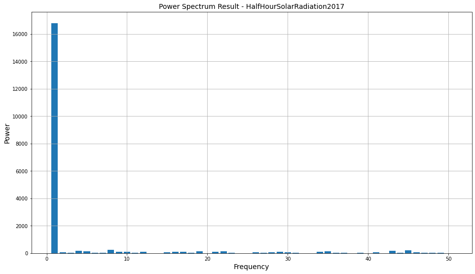

```
we can identify that 5 most important frequencies are:  [ 1  8 45 43  4]
```

```python
#find out which frequencies are important

PS_result2017.sort_values(by=['power'],ascending=False,inplace=True)
print(PS_result2017)

plt.figure(figsize=(16,9))
plt.bar(PS_result2017['frequency'], PS_result2017['power'])
plt.title('Power Spectrum Result - HalfHourSolarRadiation2017', fontsize=14)
plt.xlabel('Frequency', fontsize=14)
plt.ylabel('Power', fontsize=14)
plt.grid(True)
plt.show()

#we can identify 5 important frequencies from the below result and chart
important_frequencies = PS_result2017['frequency'][:5].values
print('we can identify that 5 most important frequencies are: ',important_frequencies)
```

**Use File c to find the Fourier series model for the seasonality. Note that the Template is designed for hourly data. You will have to make some adjustment to use it for half hourly data plus change the relevant frequencies if necessar**y.

```python
#Define time intervals for half-hourly data
time_intervals = np.arange(1,solar_radia2017.shape[0]+1)

# setting frequencies
frequencies = [1,364,365,366,730]
a_list = [-128.6899753,87.08261942,-263.346882,90.51225331,109.2062286]
b_list = [14.97013864,1.911366892,21.43218589,-17.0102398,-17.22103819]

def calculate_fourier_series(data, t, frequencies):
    fsm_result = pd.DataFrame(columns=['data','t'])
    fsm_result['data'] = data
    fsm_result['t'] = t

    for i in range(len(frequencies)):
        freq_results = []
        w = 2 * np.pi * frequencies[i] / len(data)
        for j in range(len(data)):
            freq_result = a_list[i]*np.cos(w * t[j]) + b_list[i]*np.sin(w * t[j])
            freq_results.append(freq_result)
        fsm_result[str(frequencies[i])] = freq_results

    fsm_result['model'] = np.mean(data)+fsm_result['1']+fsm_result['364']+fsm_result['365']+fsm_result['366']+fsm_result['730']
    return fsm_result
```

```python
#Fourier series model结果
FS_2017 = calculate_fourier_series(solar_radia2017['GHI'],time_intervals,frequencies)
FS_2017
```

|  | data | t | 1 | 364 | 365 | 366 | 730 | model |
| --- | --- | --- | --- | --- | --- | --- | --- | --- |
| 0 | 0.0 | 1 | -128.684598 | 86.590490 | -258.296451 | 87.507336 | 101.027984 | 59.181927 |
| 1 | 0.0 | 2 | -128.679205 | 84.624869 | -248.826497 | 82.996940 | 85.964849 | 47.118123 |
| 2 | 0.0 | 3 | -128.673795 | 81.219205 | -235.099052 | 77.058663 | 65.043352 | 30.585540 |
| 3 | 0.0 | 4 | -128.668368 | 76.431452 | -217.348997 | 69.794666 | 39.689258 | 10.935177 |
| 4 | 0.0 | 5 | -128.662925 | 70.343081 | -195.880040 | 61.329920 | 11.630406 | -10.202392 |
| ... | ... | ... | ... | ... | ... | ... | ... | ... |
| 17515 | 0.0 | 17516 | -128.711318 | 74.524836 | -238.781183 | 86.847153 | 69.516971 | 34.433625 |
| 17516 | 0.0 | 17517 | -128.706007 | 79.760109 | -251.502537 | 90.111545 | 89.397578 | 50.097854 |
| 17517 | 0.0 | 17518 | -128.700680 | 83.638122 | -259.920612 | 91.825656 | 103.185887 | 61.065539 |
| 17518 | 0.0 | 17519 | -128.695336 | 86.092883 | -263.891375 | 91.959996 | 109.942249 | 66.445583 |
| 17519 | 0.0 | 17520 | -128.689975 | 87.082619 | -263.346882 | 90.512253 | 109.206229 | 65.801410 |

17520 rows × 8 columns

**Take the difference between the data and the Fourier model - the residuals - and take them to Minitab and find the best ARMA(p,q) model**.y.

```python
#Find the best ARMA(p,q) model based on AIC。
# Specifically, use the AIC criterion to estimate the parameters of the ARMA model, ie (p, q)
# and traverse the model parameters that minimize the AIC value

import statsmodels.api as sm
from statsmodels.tsa.arima_model import ARMA

# Calculate the residuals
FS_2017['residual'] = FS_2017['data'] - FS_2017['model']

# Use the AIC criterion to estimate the parameters of the ARMA model, that is, (p, q)
# and traverse the model parameters that minimize the AIC value.

AIC_value = []

for ari in range(0,5):
    for maj in range(0,5):
        try:
            arma_object = ARMA(FS_2017['residual'],order=(ari,maj)).fit()
            AIC_value.append([ari,maj,arma_object.aic])
        except:
            print('wrong parameters')

print(AIC_value)
```

[output not shown]

[output not shown]

[output not shown]

[output not shown]

[output not shown]

[output not shown]

[output not shown]

[output not shown]

[output not shown]

[output not shown]

[output not shown]

[output not shown]

[output not shown]

[output not shown]

[output not shown]

```
参数错误
[[0, 0, 211388.87805141232], [0, 1, 197840.21810162504], [0, 2, 191895.1496084988], [0, 3, 188499.027497044], [0, 4, 187138.55012778676], [1, 0, 184403.83699114464], [2, 0, 184402.88350117736], [3, 0, 184348.08741192293], [4, 0, 184318.50442182604]]
```

According to the results, when (p, q) = (4, 0), the AIC value is the smallest. Therefore, (4,0) is the best model parameter for ARMA.

```python
# get the best model
best_arma = ARMA(FS_2017['residual'].tolist(),order=(4,0)).fit()
print(best_arma.summary())
```

```
                              ARMA Model Results
==============================================================================
Dep. Variable:                      y   No. Observations:                17520
Model:                     ARMA(4, 0)   Log Likelihood              -92153.252
Method:                       css-mle   S.D. of innovations             46.568
Date:                Mon, 04 Sep 2023   AIC                         184318.504
Time:                        01:34:25   BIC                         184365.131
Sample:                             0   HQIC                        184333.858

==============================================================================
                 coef    std err          z      P>|z|      [0.025      0.975]
------------------------------------------------------------------------------
const         -0.0366      2.846     -0.013      0.990      -5.616       5.542
ar.L1.y        0.8732      0.008    115.688      0.000       0.858       0.888
ar.L2.y        0.0654      0.010      6.527      0.000       0.046       0.085
ar.L3.y       -0.0197      0.010     -1.968      0.049      -0.039   -8.44e-05
ar.L4.y       -0.0424      0.008     -5.622      0.000      -0.057      -0.028
                                    Roots
=============================================================================
                  Real          Imaginary           Modulus         Frequency
-----------------------------------------------------------------------------
AR.1            1.1699           -0.0000j            1.1699           -0.0000
AR.2            2.2343           -0.0000j            2.2343           -0.0000
AR.3           -1.9345           -2.2963j            3.0026           -0.3614
AR.4           -1.9345           +2.2963j            3.0026            0.3614
-----------------------------------------------------------------------------
```

**Use the ARMA model to forecast one step ahead for the residuals and add that to the Fourier series model to get the full one step ahead forecast.**

```python
#forecast one step ahead for the residuals
FS_2017['pred_residuals'] = best_arma.predict(0,FS_2017.shape[0]-1)

#add that to the Fourier series model
FS_2017['pred_GHI'] = FS_2017['model'] + FS_2017['pred_residuals']
FS_2017
```

|  | data | t | 1 | 364 | 365 | 366 | 730 | model | residual | pred_residuals | pred_GHI |
| --- | --- | --- | --- | --- | --- | --- | --- | --- | --- | --- | --- |
| 0 | 0.0 | 1 | -128.684598 | 86.590490 | -258.296451 | 87.507336 | 101.027984 | 59.181927 | -59.181927 | -0.036634 | 59.145293 |
| 1 | 0.0 | 2 | -128.679205 | 84.624869 | -248.826497 | 82.996940 | 85.964849 | 47.118123 | -47.118123 | -52.461725 | -5.343602 |
| 2 | 0.0 | 3 | -128.673795 | 81.219205 | -235.099052 | 77.058663 | 65.043352 | 30.585540 | -30.585540 | -41.994793 | -11.409254 |
| 3 | 0.0 | 4 | -128.668368 | 76.431452 | -217.348997 | 69.794666 | 39.689258 | 10.935177 | -10.935177 | -26.375489 | -15.440312 |
| 4 | 0.0 | 5 | -128.662925 | 70.343081 | -195.880040 | 61.329920 | 11.630406 | -10.202392 | 10.202392 | -8.112879 | -18.315271 |
| ... | ... | ... | ... | ... | ... | ... | ... | ... | ... | ... | ... |
| 17515 | 0.0 | 17516 | -128.711318 | 74.524836 | -238.781183 | 86.847153 | 69.516971 | 34.433625 | -34.433625 | -15.512995 | 18.920631 |
| 17516 | 0.0 | 17517 | -128.706007 | 79.760109 | -251.502537 | 90.111545 | 89.397578 | 50.097854 | -50.097854 | -32.311371 | 17.786483 |
| 17517 | 0.0 | 17518 | -128.700680 | 83.638122 | -259.920612 | 91.825656 | 103.185887 | 61.065539 | -61.065539 | -45.934854 | 15.130685 |
| 17518 | 0.0 | 17519 | -128.695336 | 86.092883 | -263.891375 | 91.959996 | 109.942249 | 66.445583 | -66.445583 | -55.272748 | 11.172835 |
| 17519 | 0.0 | 17520 | -128.689975 | 87.082619 | -263.346882 | 90.512253 | 109.206229 | 65.801410 | -65.801410 | -59.569405 | 6.232006 |

17520 rows × 11 columns

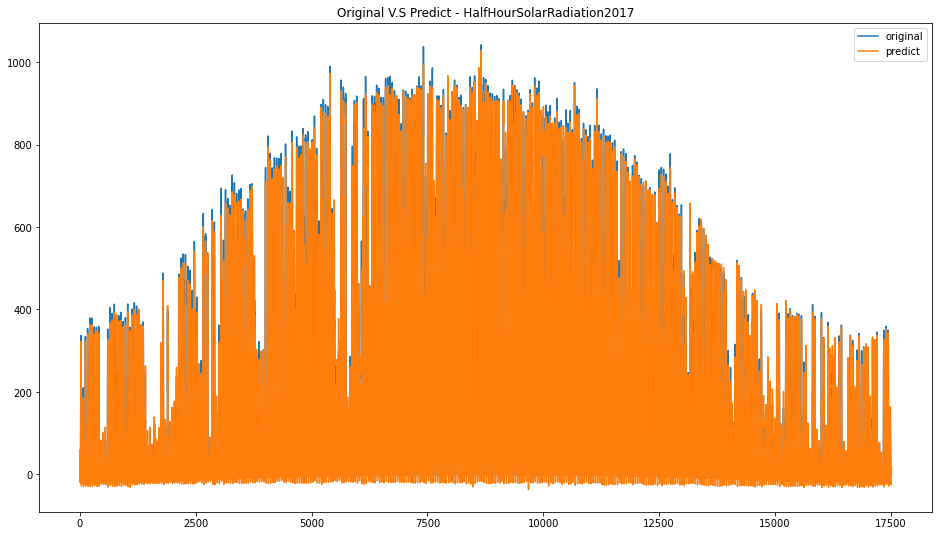

```python
plt.figure(figsize=(16,9))
plt.plot(FS_2017['t'],FS_2017['data'],label='original')
plt.plot(FS_2017['t'],FS_2017['pred_GHI'],label='predict')
plt.title('Original V.S Predict - HalfHourSolarRadiation2017')
plt.legend()
plt.show()
```

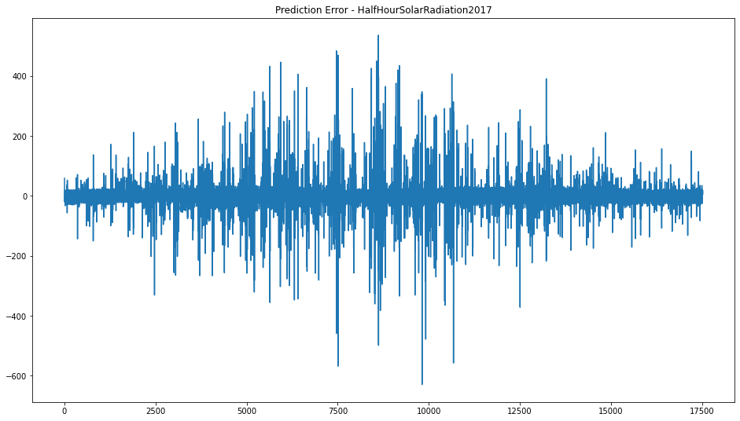

```python
plt.figure(figsize=(16,9))
plt.plot(FS_2017['t'],FS_2017['pred_GHI']-FS_2017['data'])
plt.title('Prediction Error - HalfHourSolarRadiation2017')
plt.show()
```

**Use the error metrics defined below to evaluate the model.**

```python
def NMBE(true_value,model_value):
    diffs = []
    for i in range(len(true_value)):
        diffs.append(true_value[i]-model_value[i])
    NMBE_value = np.sum(diffs)/(len(true_value)*np.mean(true_value))
    return NMBE_value


def NMAE(true_value,model_value):
    diffs = []
    for i in range(len(true_value)):
        diffs.append(abs(true_value[i]-model_value[i]))
    NMAE_value = np.sum(diffs)/(len(true_value)*np.mean(true_value))
    return NMAE_value
```

```python
#for solar radiation, we only do the calculation for solar elevation greater than or equal to 10 degrees
FS_2017['Elevation'] = solar_radia2017['Elevation']
solar_radia_pred_df = FS_2017[FS_2017['Elevation']>=10].reset_index(drop=True)

#calculate NMBE
NMBE_value = NMBE(solar_radia_pred_df['data'],solar_radia_pred_df['pred_GHI'])
print('NMBE: ',NMBE_value)

#calculate NMAE
NMAE_value = NMAE(solar_radia_pred_df['data'],solar_radia_pred_df['pred_GHI'])
print('NMAE: ',NMAE_value)
```

```
NMBE:  0.0005764058614954701
NMAE:  0.10672634392416983
```

**Use the models you have developed for 2017 to see how they perform for the 2018 data, the out of sample data. Comment on the differences in the error metrics**

```python
solar_radia2018 = pd.read_excel('HalfHourSolarRadiation2018.xlsx',sheet_name='Sheet1')

FS_2018 = calculate_fourier_series(solar_radia2018['Solar'],FS_2017.shape[0]+time_intervals,frequencies)
FS_2018['pred_Solar'] = FS_2018['model'] + best_arma.predict(FS_2018['t'][0],FS_2017.shape[0]+solar_radia2018.shape[0]-1)
FS_2018
```

|  | data | t | 1 | 364 | 365 | 366 | 730 | model | pred_Solar |
| --- | --- | --- | --- | --- | --- | --- | --- | --- | --- |
| 0 | 0.0 | 17521 | -128.684598 | 86.590490 | -258.296451 | 87.507336 | 101.027984 | 49.067076 | -9.410699 |
| 1 | 0.0 | 17522 | -128.679205 | 84.624869 | -248.826497 | 82.996940 | 85.964849 | 37.003272 | -14.465873 |
| 2 | 0.0 | 17523 | -128.673795 | 81.219205 | -235.099052 | 77.058663 | 65.043352 | 20.470689 | -24.183895 |
| 3 | 0.0 | 17524 | -128.668368 | 76.431452 | -217.348997 | 69.794666 | 39.689258 | 0.820326 | -37.597180 |
| 4 | 0.0 | 17525 | -128.662925 | 70.343081 | -195.880040 | 61.329920 | 11.630406 | -20.317243 | -53.291848 |
| ... | ... | ... | ... | ... | ... | ... | ... | ... | ... |
| 17515 | 0.0 | 35036 | -128.711318 | 74.524836 | -238.781183 | 86.847153 | 69.516971 | 24.318774 | 24.282140 |
| 17516 | 0.0 | 35037 | -128.706007 | 79.760109 | -251.502537 | 90.111545 | 89.397578 | 39.983003 | 39.946370 |
| 17517 | 0.0 | 35038 | -128.700680 | 83.638122 | -259.920612 | 91.825656 | 103.185887 | 50.950688 | 50.914054 |
| 17518 | 0.0 | 35039 | -128.695336 | 86.092883 | -263.891375 | 91.959996 | 109.942249 | 56.330733 | 56.294099 |
| 17519 | 0.0 | 35040 | -128.689975 | 87.082619 | -263.346882 | 90.512253 | 109.206229 | 55.686559 | 55.649926 |

17520 rows × 9 columns

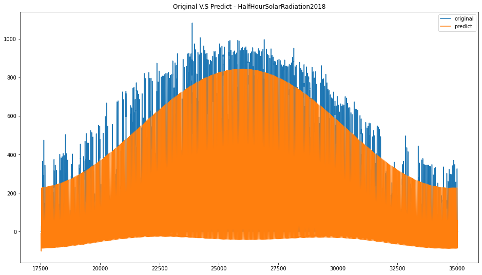

```python
plt.figure(figsize=(16,9))
plt.plot(FS_2018['t'],FS_2018['data'],label='original')
plt.plot(FS_2018['t'],FS_2018['pred_Solar'],label='predict')
plt.title('Original V.S Predict - HalfHourSolarRadiation2018')
plt.legend()
plt.show()
```

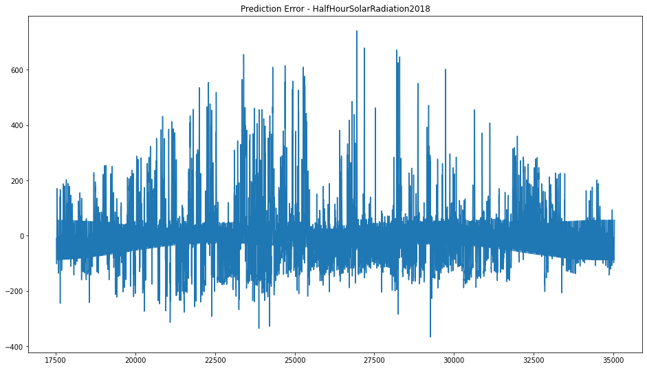

```python
plt.figure(figsize=(16,9))
plt.plot(FS_2018['t'],FS_2018['pred_Solar']-FS_2018['data'])
plt.title('Prediction Error - HalfHourSolarRadiation2018')
plt.show()
```

```python
FS_2018['Elevation'] = solar_radia2018['Elevation']

solar_radia_pred_df2018 = FS_2018[FS_2018['Elevation']>=10].reset_index(drop=True)

#calculate NMBE
NMBE_value = NMBE(solar_radia_pred_df2018['data'],solar_radia_pred_df2018['pred_Solar'])
print('NMBE: ',NMBE_value)

#calculate NMAE
NMAE_value = NMAE(solar_radia_pred_df2018['data'],solar_radia_pred_df2018['pred_Solar'])
print('NMAE: ',NMAE_value)
```

```
NMBE:  -0.03731455570097423
NMAE:  0.3165742182418225
```

But compared with the error metrics of the ARMA model on the 2017 data (NMBE: 0.0005764058614954701; NMAE: 0.10672634392416983), its performance on the 2018 data is worse.

## Question 2

```python
#use the power spectrum to decide on the necessary frequencies
solar_farm = pd.read_excel('SolarFarm.xlsx',sheet_name='Sheet1')

num_frequencies = 50
PS_result_SolarFarm = calculate_dft(solar_farm.Output, num_frequencies)
PS_result_SolarFarm
```

|  | frequency | ai | bi | power |
| --- | --- | --- | --- | --- |
| 0 | 1 | 14.789658 | 0.146161 | 4.238366 |
| 1 | 2 | -0.654833 | 0.725198 | 0.954719 |
| 2 | 3 | 0.188253 | -0.908364 | 0.860564 |
| 3 | 4 | 0.295985 | -0.158863 | 0.112845 |
| 4 | 5 | 0.376397 | -0.178873 | 0.173670 |
| 5 | 6 | 0.609140 | -0.127232 | 0.387239 |
| 6 | 7 | -0.085552 | 0.011051 | 0.007441 |
| 7 | 8 | 0.471443 | 0.537855 | 0.511546 |
| 8 | 9 | -0.070038 | 0.140644 | 0.024686 |
| 9 | 10 | 0.092156 | 0.076483 | 0.014342 |
| 10 | 11 | -0.041695 | -0.209945 | 0.045815 |
| 11 | 12 | -0.034183 | 0.148884 | 0.023335 |
| 12 | 13 | -0.076381 | -0.160276 | 0.031522 |
| 13 | 14 | -0.449367 | -0.567574 | 0.524071 |
| 14 | 15 | 0.023546 | -0.006046 | 0.000591 |
| 15 | 16 | 0.330498 | -0.494301 | 0.353563 |
| 16 | 17 | 0.109381 | -0.669173 | 0.459757 |
| 17 | 18 | -0.731622 | -0.298799 | 0.624552 |
| 18 | 19 | 0.156278 | 0.165745 | 0.051894 |
| 19 | 20 | 0.246235 | 0.161421 | 0.086689 |
| 20 | 21 | -0.513910 | 0.220348 | 0.312657 |
| 21 | 22 | 0.105736 | 0.845238 | 0.725607 |
| 22 | 23 | 0.116900 | 0.009992 | 0.013765 |
| 23 | 24 | 0.244219 | 0.074966 | 0.065263 |
| 24 | 25 | -0.271806 | 0.398671 | 0.232817 |
| 25 | 26 | 0.417810 | 0.290567 | 0.258994 |
| 26 | 27 | -0.088538 | -0.016542 | 0.008113 |
| 27 | 28 | -0.024912 | -0.340409 | 0.116499 |
| 28 | 29 | 0.094252 | 0.252475 | 0.072627 |
| 29 | 30 | 0.303112 | 0.138229 | 0.110984 |
| 30 | 31 | 0.302653 | -0.066050 | 0.095961 |
| 31 | 32 | -0.432586 | 0.380604 | 0.331990 |
| 32 | 33 | -0.183501 | 0.340598 | 0.149680 |
| 33 | 34 | 0.221506 | 0.700209 | 0.539357 |
| 34 | 35 | -0.298174 | -0.564355 | 0.407404 |
| 35 | 36 | -0.417969 | -0.344050 | 0.293069 |
| 36 | 37 | -0.425556 | -0.332561 | 0.291695 |
| 37 | 38 | 0.177228 | -0.227421 | 0.083130 |
| 38 | 39 | -0.498321 | -0.070083 | 0.253236 |
| 39 | 40 | 0.397390 | 0.054352 | 0.160873 |
| 40 | 41 | 0.385312 | 0.345111 | 0.267567 |
| 41 | 42 | 0.152556 | 0.150711 | 0.045987 |
| 42 | 43 | 0.321197 | 0.124025 | 0.118550 |
| 43 | 44 | -0.113881 | -0.024682 | 0.013578 |
| 44 | 45 | -0.569391 | 0.251811 | 0.387615 |
| 45 | 46 | -0.110359 | 0.170574 | 0.041274 |
| 46 | 47 | 0.188940 | 0.543942 | 0.331571 |
| 47 | 48 | -0.309960 | 0.104127 | 0.106918 |
| 48 | 49 | 0.169284 | -0.317936 | 0.129740 |
| 49 | 50 | 0.098403 | -0.405488 | 0.174103 |

```
    frequency         ai        bi     power
0           1  14.789658  0.146161  4.238366
1           2  -0.654833  0.725198  0.954719
2           3   0.188253 -0.908364  0.860564
21         22   0.105736  0.845238  0.725607
17         18  -0.731622 -0.298799  0.624552
33         34   0.221506  0.700209  0.539357
13         14  -0.449367 -0.567574  0.524071
7           8   0.471443  0.537855  0.511546
16         17   0.109381 -0.669173  0.459757
34         35  -0.298174 -0.564355  0.407404
44         45  -0.569391  0.251811  0.387615
5           6   0.609140 -0.127232  0.387239
15         16   0.330498 -0.494301  0.353563
31         32  -0.432586  0.380604  0.331990
```

[output cut: 36 more lines]

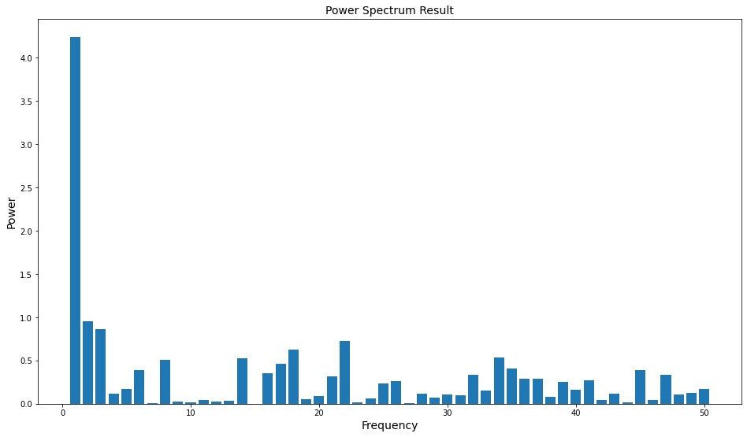

```
we can identify that the important frequencies for solar farm output are:  [ 1  2  3 22 18]
```

```python
#find out which frequencies are important

PS_result_SolarFarm.sort_values(by=['power'],ascending=False,inplace=True)
print(PS_result_SolarFarm)

plt.figure(figsize=(16,9))
plt.bar(PS_result_SolarFarm['frequency'], PS_result_SolarFarm['power'])
plt.title('Power Spectrum Result', fontsize=14)
plt.xlabel('Frequency', fontsize=14)
plt.ylabel('Power', fontsize=14)
plt.show()

#we can identify important frequencies from the below result and chart
important_frequencies = PS_result_SolarFarm['frequency'][:5].values
print('we can identify that the important frequencies for solar farm output are: ',important_frequencies)
```

```python
#find the Fourier series model

time_intervals = np.arange(1,solar_farm.shape[0]+1)

FS_solar_farm = calculate_fourier_series(solar_farm['Output'],time_intervals,frequencies)
FS_solar_farm
```

|  | data | t | 1 | 364 | 365 | 366 | 730 | model |
| --- | --- | --- | --- | --- | --- | --- | --- | --- |
| 0 | 0.0 | 1 | -128.689080 | 87.103592 | -262.816672 | 90.118503 | 108.351117 | -91.142883 |
| 1 | 0.0 | 2 | -128.688185 | 87.083334 | -262.161375 | 89.681625 | 107.289754 | -92.005190 |
| 2 | 0.0 | 3 | -128.687289 | 87.021856 | -261.381304 | 89.201830 | 106.024158 | -93.031091 |
| 3 | 0.0 | 4 | -128.686392 | 86.919187 | -260.476830 | 88.679347 | 104.556739 | -94.218292 |
| 4 | 0.0 | 5 | -128.685496 | 86.775376 | -259.448382 | 88.114425 | 102.890290 | -95.564129 |
| ... | ... | ... | ... | ... | ... | ... | ... | ... |
| 105115 | 0.0 | 105116 | -128.693551 | 86.586925 | -264.212706 | 91.652530 | 110.537543 | -89.339602 |
| 105116 | 0.0 | 105117 | -128.692658 | 86.772521 | -264.184768 | 91.432963 | 110.519751 | -89.362533 |
| 105117 | 0.0 | 105118 | -128.691764 | 86.917045 | -264.031093 | 91.169641 | 110.291578 | -89.554935 |
| 105118 | 0.0 | 105119 | -128.690870 | 87.020427 | -263.751753 | 90.862689 | 109.853460 | -89.916390 |
| 105119 | 0.0 | 105120 | -128.689975 | 87.082619 | -263.346882 | 90.512253 | 109.206229 | -90.446098 |

105120 rows × 8 columns

Similarly, use the AIC criterion to estimate the parameters of the ARMA model, ie (p, q), and traverse the model parameters that minimize the AIC value

```python
import statsmodels.api as sm
from statsmodels.tsa.arima_model import ARMA

# Calculate the residuals
FS_solar_farm['residual'] = FS_solar_farm['data'] - FS_solar_farm['model']

# Use the AIC criterion to estimate the parameters of the ARMA model, ie (p,q)

AIC_value = []

for ari in range(0,5):
    for maj in range(0,5):
        try:
            arma_object = ARMA(FS_solar_farm['residual'],order=(ari,maj)).fit()
            AIC_value.append([ari,maj,arma_object.aic])
        except:
            print('Wrong Parameters')

print(AIC_value)
```

[output not shown]

```python
# get the best armr model
#best_arma = ARMA(FS_solar_farm['residual'].tolist(),order=(2,1)).fit()

#forecast one step ahead for the residuals
FS_solar_farm['pred_residuals'] = best_arma.predict(0,FS_solar_farm.shape[0]-1)

#add that to the Fourier series model
FS_solar_farm['pred_Output'] = FS_solar_farm['model'] + FS_solar_farm['pred_residuals']
FS_solar_farm
```

|  | data | t | 1 | 364 | 365 | 366 | 730 | model | residual | pred_residuals | pred_Output |
| --- | --- | --- | --- | --- | --- | --- | --- | --- | --- | --- | --- |
| 0 | 0.0 | 1 | -128.689080 | 87.103592 | -262.816672 | 90.118503 | 108.351117 | -91.142883 | 91.142883 | 5.315180 | -85.827703 |
| 1 | 0.0 | 2 | -128.688185 | 87.083334 | -262.161375 | 89.681625 | 107.289754 | -92.005190 | 92.005190 | 5.314167 | -86.691023 |
| 2 | 0.0 | 3 | -128.687289 | 87.021856 | -261.381304 | 89.201830 | 106.024158 | -93.031091 | 93.031091 | 5.311093 | -87.719999 |
| 3 | 0.0 | 4 | -128.686392 | 86.919187 | -260.476830 | 88.679347 | 104.556739 | -94.218292 | 94.218292 | 5.305959 | -88.912332 |
| 4 | 0.0 | 5 | -128.685496 | 86.775376 | -259.448382 | 88.114425 | 102.890290 | -95.564129 | 95.564129 | 5.298769 | -90.265360 |
| ... | ... | ... | ... | ... | ... | ... | ... | ... | ... | ... | ... |
| 105115 | 0.0 | 105116 | -128.693551 | 86.586925 | -264.212706 | 91.652530 | 110.537543 | -89.339602 | 89.339602 | 5.289346 | -84.050256 |
| 105116 | 0.0 | 105117 | -128.692658 | 86.772521 | -264.184768 | 91.432963 | 110.519751 | -89.362533 | 89.362533 | 5.298626 | -84.063907 |
| 105117 | 0.0 | 105118 | -128.691764 | 86.917045 | -264.031093 | 91.169641 | 110.291578 | -89.554935 | 89.554935 | 5.305852 | -84.249083 |
| 105118 | 0.0 | 105119 | -128.690870 | 87.020427 | -263.751753 | 90.862689 | 109.853460 | -89.916390 | 89.916390 | 5.311021 | -84.605368 |
| 105119 | 0.0 | 105120 | -128.689975 | 87.082619 | -263.346882 | 90.512253 | 109.206229 | -90.446098 | 90.446098 | 5.314131 | -85.131967 |

105120 rows × 11 columns

```python
solar_farm_pred = FS_solar_farm[FS_solar_farm['data']>0].reset_index(drop=True)

#calculate NMBE
NMBE_value = NMBE(solar_farm_pred['data'],solar_farm_pred['pred_Output'])
print('NMBE: ',NMBE_value)

#calculate NMAE
NMAE_value = NMAE(solar_farm_pred['data'],solar_farm_pred['pred_Output'])
print('NMAE: ',NMAE_value)
```

```
NMBE:  -4.589187327708524
NMAE:  7.175711416139246
```

## Question 3

```python
wind_farm = pd.read_excel('SnowtownWindFarm.xlsx',sheet_name='Sheet1')
wind_farm
```

|  | Snowtown |
| --- | --- |
| 0 | 84.198322 |
| 1 | 84.117132 |
| 2 | 81.609137 |
| 3 | 79.826108 |
| 4 | 75.148393 |
| ... | ... |
| 17515 | 38.392713 |
| 17516 | 46.934388 |
| 17517 | 53.936237 |
| 17518 | 58.116488 |
| 17519 | 58.070410 |

17520 rows × 1 columns

```python
#Use the power spectrum file from above to show that there is no significant seasonality in the data

num_frequencies = 50

PS_result_windFarm = calculate_dft(wind_farm.Snowtown, num_frequencies)
PS_result_windFarm
```

|  | frequency | ai | bi | power |
| --- | --- | --- | --- | --- |
| 0 | 1 | 36.605356 | 0.756815 | 1.520784 |
| 1 | 2 | 2.995149 | 0.352905 | 9.095458 |
| 2 | 3 | 1.909071 | 1.988578 | 7.598997 |
| 3 | 4 | 1.435534 | 1.411307 | 4.052545 |
| 4 | 5 | -1.581604 | 1.127824 | 3.773458 |
| 5 | 6 | 1.341553 | -1.480244 | 3.990889 |
| 6 | 7 | 0.758636 | -1.026324 | 1.628870 |
| 7 | 8 | -0.435229 | 1.177705 | 1.576414 |
| 8 | 9 | -1.719059 | -2.022673 | 7.046370 |
| 9 | 10 | 1.534883 | 2.130692 | 6.895716 |
| 10 | 11 | -1.663518 | -1.077311 | 3.927893 |
| 11 | 12 | 2.262251 | 1.021960 | 6.162180 |
| 12 | 13 | 0.616326 | 0.277349 | 0.456780 |
| 13 | 14 | 0.870656 | -1.763459 | 3.867831 |
| 14 | 15 | -3.419908 | 2.938028 | 20.327782 |
| 15 | 16 | -1.360392 | -1.828568 | 5.194326 |
| 16 | 17 | -0.998102 | -1.263728 | 2.593218 |
| 17 | 18 | 4.184620 | -1.569606 | 19.974710 |
| 18 | 19 | -4.195564 | 0.177137 | 17.634132 |
| 19 | 20 | 4.103955 | -3.316293 | 27.840249 |
| 20 | 21 | 2.196765 | 3.527584 | 17.269620 |
| 21 | 22 | -0.849624 | -0.869396 | 1.477711 |
| 22 | 23 | 0.125770 | 0.508548 | 0.274440 |
| 23 | 24 | 0.215775 | 1.700361 | 2.937786 |
| 24 | 25 | 2.482703 | 0.624639 | 6.553988 |
| 25 | 26 | -3.555153 | -0.983289 | 13.605972 |
| 26 | 27 | 2.834060 | 1.757737 | 11.121537 |
| 27 | 28 | -0.854909 | -0.348624 | 0.852408 |
| 28 | 29 | -1.434278 | -0.178809 | 2.089127 |
| 29 | 30 | 1.534130 | -1.454036 | 4.467775 |
| 30 | 31 | -0.316538 | 2.251581 | 5.169813 |
| 31 | 32 | 0.540457 | -0.608305 | 0.662129 |
| 32 | 33 | 0.018394 | -1.540963 | 2.374907 |
| 33 | 34 | 3.010750 | 0.119057 | 9.078790 |
| 34 | 35 | 3.449838 | 3.658955 | 25.289334 |
| 35 | 36 | -0.065630 | -3.263489 | 10.654670 |
| 36 | 37 | 0.869409 | 1.318868 | 2.495286 |
| 37 | 38 | 1.467529 | 0.123240 | 2.168829 |
| 38 | 39 | -1.027784 | -4.157671 | 18.342569 |
| 39 | 40 | 0.362237 | -0.624291 | 0.520955 |
| 40 | 41 | -1.403006 | -0.189705 | 2.004414 |
| 41 | 42 | 1.110790 | -0.814845 | 1.897827 |
| 42 | 43 | 0.024746 | 1.183959 | 1.402371 |
| 43 | 44 | -3.289056 | 0.461414 | 11.030790 |
| 44 | 45 | 2.455552 | -2.048016 | 10.224104 |
| 45 | 46 | -3.636081 | 5.010479 | 38.325991 |
| 46 | 47 | -0.749762 | 0.063575 | 0.566185 |
| 47 | 48 | 2.209391 | -1.196004 | 6.311831 |
| 48 | 49 | -1.376302 | -0.365793 | 2.028011 |
| 49 | 50 | -0.494605 | 1.898355 | 3.848387 |

```
    frequency         ai        bi      power
45         46  -3.636081  5.010479  38.325991
19         20   4.103955 -3.316293  27.840249
34         35   3.449838  3.658955  25.289334
14         15  -3.419908  2.938028  20.327782
17         18   4.184620 -1.569606  19.974710
38         39  -1.027784 -4.157671  18.342569
18         19  -4.195564  0.177137  17.634132
20         21   2.196765  3.527584  17.269620
25         26  -3.555153 -0.983289  13.605972
26         27   2.834060  1.757737  11.121537
43         44  -3.289056  0.461414  11.030790
35         36  -0.065630 -3.263489  10.654670
44         45   2.455552 -2.048016  10.224104
1           2   2.995149  0.352905   9.095458
```

[output cut: 36 more lines]

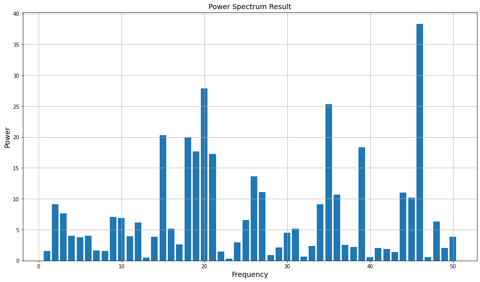

```
we can identify that 5 most important frequencies are:  [46 20 35 15 18]
```

```python
#find out which frequencies are important

PS_result_windFarm.sort_values(by=['power'],ascending=False,inplace=True)
print(PS_result_windFarm)

plt.figure(figsize=(16,9))
plt.bar(PS_result_windFarm['frequency'], PS_result_windFarm['power'])
plt.title('Power Spectrum Result', fontsize=14)
plt.xlabel('Frequency', fontsize=14)
plt.ylabel('Power', fontsize=14)
plt.grid(True)
plt.show()

#we can identify important frequencies from the below result and chart
important_frequencies = PS_result_windFarm['frequency'][:5].values
print('we can identify that 5 most important frequencies are: ',important_frequencies)
```

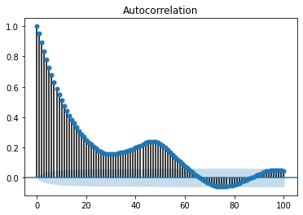

```python
import statsmodels.api as sm
from statsmodels.tsa.ar_model import AutoReg
from statsmodels.graphics.tsaplots import plot_acf, plot_pacf

# Calculate the acf and pacf of the wind_farm data to determine the optimal order p of the AR model
acf_plot = plot_acf(wind_farm['Snowtown'], lags=100)

# According to the autoregressive graph, the lag value should be selected as [1,2,3,4,5,45]
lags = [1,2,3,4,5,45]
```

```python
best_ar = AutoReg(wind_farm['Snowtown'], lags = lags, seasonal = False).fit()
print(best_ar.summary())
```

```
                            AutoReg Model Results
==============================================================================
Dep. Variable:               Snowtown   No. Observations:                17520
Model:             Restr. AutoReg(45)   Log Likelihood              -63139.604
Method:               Conditional MLE   S.D. of innovations              8.973
Date:                Mon, 04 Sep 2023   AIC                              4.389
Time:                        01:44:03   BIC                              4.393
Sample:                            45   HQIC                             4.390
                                17520
================================================================================
                   coef    std err          z      P>|z|      [0.025      0.975]
--------------------------------------------------------------------------------
intercept        1.4934      0.127     11.793      0.000       1.245       1.742
Snowtown.L1      1.1481      0.008    151.708      0.000       1.133       1.163
Snowtown.L2     -0.2630      0.012    -22.838      0.000      -0.286      -0.240
Snowtown.L3      0.0893      0.012      7.654      0.000       0.066       0.112
Snowtown.L4     -0.0274      0.012     -2.383      0.017      -0.050      -0.005
Snowtown.L5     -0.0057      0.008     -0.760      0.447      -0.021       0.009
Snowtown.L45     0.0179      0.002      7.843      0.000       0.013       0.022
                                    Roots
==============================================================================
                   Real          Imaginary           Modulus         Frequency
------------------------------------------------------------------------------
AR.1             1.0201           -0.0000j            1.0201           -0.0000
AR.2             1.0305           -0.1168j            1.0371           -0.0180
AR.3             1.0305           +0.1168j            1.0371            0.0180
AR.4             1.0224           -0.2583j            1.0545           -0.0394
AR.5             1.0224           +0.2583j            1.0545            0.0394
AR.6             0.9869           -0.4017j            1.0655           -0.0615
AR.7             0.9869           +0.4017j            1.0655            0.0615
AR.8             0.9280           -0.5396j            1.0735           -0.0838
AR.9             0.9280           +0.5396j            1.0735            0.0838
AR.10            0.8481           -0.6682j            1.0797           -0.1062
AR.11            0.8481           +0.6682j            1.0797            0.1062
AR.12            0.7493           -0.7844j            1.0848           -0.1286
AR.13            0.7493           +0.7844j            1.0848            0.1286
AR.14            0.6339           -0.8853j            1.0889           -0.1511
AR.15            0.6339           +0.8853j            1.0889            0.1511
AR.16            0.5047           -0.9686j            1.0922           -0.1736
AR.17            0.5047           +0.9686j            1.0922            0.1736
```

[output cut: 14 more lines]

```
AR.32           -0.6698           -0.8865j            1.1111           -0.3530
AR.33           -0.6698           +0.8865j            1.1111            0.3530
AR.34           -0.7897           -0.7845j            1.1131           -0.3755
AR.35           -0.7897           +0.7845j            1.1131            0.3755
AR.36           -1.1157           -0.0796j            1.1185           -0.4887
AR.37           -1.1157           +0.0796j            1.1185            0.4887
AR.38           -1.0927           -0.2370j            1.1181           -0.4660
AR.39           -1.0927           +0.2370j            1.1181            0.4660
AR.40           -1.0474           -0.3894j            1.1174           -0.4434
AR.41           -1.0474           +0.3894j            1.1174            0.4434
AR.42           -0.9806           -0.5334j            1.1163           -0.4207
AR.43           -0.9806           +0.5334j            1.1163            0.4207
AR.44           -0.8941           -0.6660j            1.1148           -0.3981
AR.45           -0.8941           +0.6660j            1.1148            0.3981
------------------------------------------------------------------------------
```

Use the AIC criterion to estimate the parameters of the ARMA model, that is, (p, q), and traverse the model parameters that minimize the AIC value.

```python
from statsmodels.tsa.arima_model import ARMA

AIC_value = []

for ari in range(0,5):
    for maj in range(0,5):
        try:
            arma_object = ARMA(wind_farm['Snowtown'],order=(ari,maj)).fit()
            AIC_value.append([ari,maj,arma_object.aic])
        except:
            print('Wrong Parameters')

print(AIC_value)
```

[output not shown]

[output not shown]

[output not shown]

[output not shown]

[output not shown]

[output not shown]

[output not shown]

[output not shown]

[output not shown]

[output not shown]

[output not shown]

[output not shown]

[output not shown]

[output not shown]

[output not shown]

[output not shown]

```
参数错误
[[0, 0, 169528.62942035173], [0, 1, 151001.85716047406], [1, 0, 127402.38612839137], [2, 0, 126718.32153901298], [3, 0, 126671.94064500957], [4, 0, 126654.26618513638]]
```

According to the results, when (p, q) = (4, 0), the AIC value is the smallest. Therefore, (4,0) is the best model parameter for ARMA.

```python
best_arma = ARMA(wind_farm['Snowtown'],order=(4,0)).fit()
print(best_arma.summary())
```

```
                              ARMA Model Results
==============================================================================
Dep. Variable:               Snowtown   No. Observations:                17520
Model:                     ARMA(4, 0)   Log Likelihood              -63321.133
Method:                       css-mle   S.D. of innovations              8.982
Date:                Mon, 04 Sep 2023   AIC                         126654.266
Time:                        01:46:13   BIC                         126700.893
Sample:                             0   HQIC                        126669.619

==================================================================================
                     coef    std err          z      P>|z|      [0.025      0.975]
----------------------------------------------------------------------------------
const             36.6608      1.253     29.253      0.000      34.204      39.117
ar.L1.Snowtown     1.1528      0.008    152.678      0.000       1.138       1.168
ar.L2.Snowtown    -0.2644      0.012    -22.983      0.000      -0.287      -0.242
ar.L3.Snowtown     0.0911      0.012      7.915      0.000       0.069       0.114
ar.L4.Snowtown    -0.0335      0.008     -4.437      0.000      -0.048      -0.019
                                    Roots
=============================================================================
                  Real          Imaginary           Modulus         Frequency
-----------------------------------------------------------------------------
AR.1            1.0722           -0.0000j            1.0722           -0.0000
AR.2            2.8779           -0.0000j            2.8779           -0.0000
AR.3           -0.6158           -3.0486j            3.1102           -0.2817
AR.4           -0.6158           +3.0486j            3.1102            0.2817
-----------------------------------------------------------------------------
```

```python
ar_preds = []
for i in range(100,500):
    ar_preds.append(best_ar.params['intercept']+best_ar.params['Snowtown.L1']*wind_farm['Snowtown'][i-1]+best_ar.params['Snowtown.L2']*wind_farm['Snowtown'][i-2]+best_ar.params['Snowtown.L3']*wind_farm['Snowtown'][i-3]+best_ar.params['Snowtown.L4']*wind_farm['Snowtown'][i-4]+best_ar.params['Snowtown.L5']*wind_farm['Snowtown'][i-5]+best_ar.params['Snowtown.L45']*wind_farm['Snowtown'][i-45])

print('AR Model NMBE: ',NMBE(wind_farm['Snowtown'][100:500].values,np.array(ar_preds)))
print('AR Model NMAE: ',NMAE(wind_farm['Snowtown'][100:500].values,np.array(ar_preds)))
```

```
AR Model NMBE:  -0.0002013561053139933
AR Model NMAE:  0.13404619691332592
```

[figure not shown]

```python
plt.figure(figsize=(16,9))
plt.plot(range(100,500),wind_farm['Snowtown'][100:500].values,label='original')
plt.plot(range(100,500),ar_preds,label='predict')
plt.title('Original V.S Predict - The Best AR Model')
plt.legend()
plt.show()
```

```python
arma_preds = best_arma.predict(100,500)

print('ARMA Model NMBE: ',NMBE(wind_farm['Snowtown'][100:500].values,arma_preds.values))
print('ARMA Model NMAE: ',NMAE(wind_farm['Snowtown'][100:500].values,arma_preds.values))
```

```
ARMA Model NMBE:  0.0009135746653356808
ARMA Model NMAE:  0.13451608620153263
```

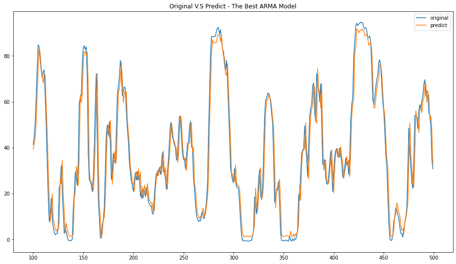

```python
plt.figure(figsize=(16,9))
plt.plot(range(100,500),wind_farm['Snowtown'][100:500].values,label='original')
plt.plot(range(100,500),arma_preds[:-1],label='predict')
plt.title('Original V.S Predict - The Best ARMA Model')
plt.legend()
plt.show()
```

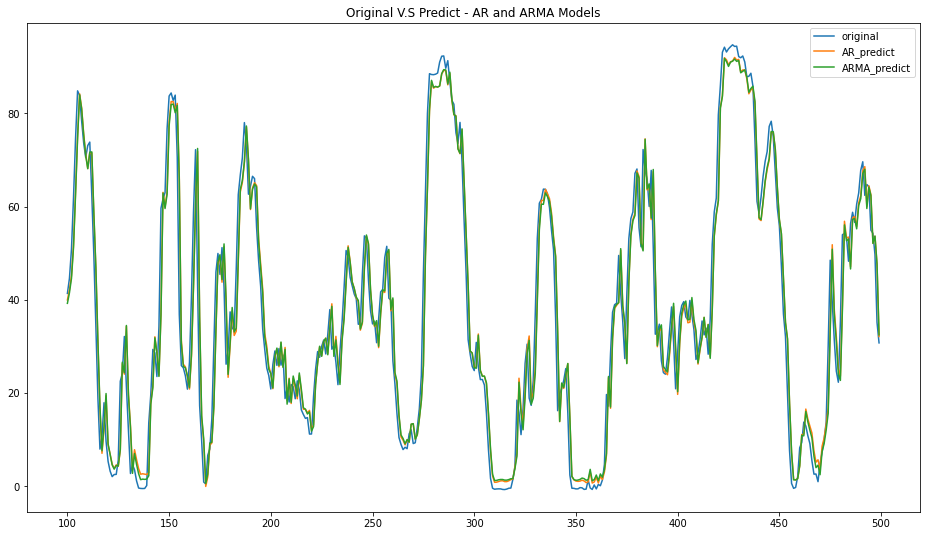

```python
plt.figure(figsize=(16,9))
plt.plot(range(100,500),wind_farm['Snowtown'][100:500].values,label='original')
plt.plot(range(100,500),ar_preds,label='AR_predict')
plt.plot(range(100,500),arma_preds[:-1],label='ARMA_predict')
plt.title('Original V.S Predict - AR and ARMA Models')
plt.legend()
plt.show()
```

Is there a difference in the number of parameters to estimate in the two models?

According to the above results, the optimal AR model and the optimal ARMA model are very similar, and the performance of the two indicators of NMBE and NMAE is also very close.

This is because the lags parameter of the optimal AR model is [1,2,3,4,5,45], and the (p,q) parameter of the optimal ARMA model is (4, 0), which means, The optimal ARMA model is actually an AR model, and the lags parameter is [1,2,3,4].

It can be seen that the parameters of the two models themselves are very close, which is why the performance of the two is almost the same.